# Part iiB: Bayesian Regression Models

INFSCI 2595 Final

Ben Stein

4/27/2022

# About this document

In this document, I evaluate two Bayesian regression models based on findings from the simple frequentist modeling done in the previous section.

**NOTE**: This document makes extensive use of code published on the course Canvas for using `rstanarm` and comparing Bayesian models.

# Setup

## Libraries and tools

```r
library(tidyverse)
library(rstanarm)
# set rstanarm options
options(mc.cores = parallel::detectCores())

source("./tools.R")
```

## Data

```r
df <- load_project_data() %>%
  select(-outcome_numeric)
```

# Models

**NOTE:** When I tried to run my best-performing model from the previous section (model 5) using `rstanarm`, I got a strange error when attempting to compute `bayes_R2`. I’ll demonstrate it here, but I’ll do Bayesian versions of the next-two-best models for this section.

```r
lm_model5 <- stan_lm(
  response_log ~ customer * (.),
  data = df %>% select(where(is.numeric), customer),
  prior = R2(location = .5),
  seed = 2022
)

bayes_R2(lm_model5)
```

```
## Error in stanmat[, beta_sel, drop = FALSE]: subscript out of bounds
```

## First Bayesian model (model 6 from the previous section)

Model 6 from the previous section was my second best-performing model from the previous section:

```r
lm_model6 <- lm(
  response_log ~ .^2,
  data = df %>% select(where(is.numeric))
)

broom::glance(lm_model6)
```

```
## # A tibble: 1 x 12
##   r.squared adj.r.squared sigma statistic       p.value    df logLik   AIC   BIC
##       <dbl>         <dbl> <dbl>     <dbl>         <dbl> <dbl>  <dbl> <dbl> <dbl>
## 1     0.924         0.556 0.357      2.51 0.00000000653   561   338.  451. 2994.
## # ... with 3 more variables: deviance <dbl>, df.residual <int>, nobs <int>
```

Let’s examine this model from a Bayesian perspective.

### Fit

```r
bayesian_model6 <- stan_lm(
  response_log ~ .^2,
  data = df %>% select(where(is.numeric)),
  prior = R2(location = .5), # starting from a weak R^2
  seed = 2022
)
```

### Summary

```r
bayesian_model6 %>% summary
```

```
##
## Model Info:
##  function:     stan_lm
##  family:       gaussian [identity]
##  formula:      response_log ~ .^2
##  algorithm:    sampling
##  sample:       4000 (posterior sample size)
##  priors:       see help('prior_summary')
##  observations: 677
##  predictors:   562
##
## Estimates:
##                 mean   sd    10%   50%   90%
## (Intercept)     0.1    0.4  -0.4   0.1   0.5
## xb_01          -0.4    1.6  -2.4  -0.4   1.6
## xb_02           0.1    0.9  -1.0   0.1   1.2
## xb_03           0.3    0.9  -0.9   0.3   1.5
## xn_01           0.7    3.1  -3.3   0.7   4.7
## xn_02          -0.7    1.4  -2.5  -0.7   1.2
## xn_03          -0.2    1.8  -2.5  -0.2   2.1
## xa_01           0.1    0.7  -0.8   0.1   1.1
## xa_02           0.0    0.4  -0.5   0.0   0.5
## xa_03          -0.1    0.4  -0.6  -0.1   0.4
## xb_04           4.3    5.4  -2.7   4.3  11.3
## xb_05          -1.7    3.1  -5.7  -1.7   2.3
## xb_06          -1.6    2.6  -5.0  -1.6   1.8
## xb_07          -0.4    0.4  -1.0  -0.4   0.2
## xb_08          -0.6    0.5  -1.2  -0.6   0.0
## xn_04          -2.7    6.7 -11.3  -2.8   5.9
## xn_05           0.6    4.2  -4.7   0.6   5.9
## xn_06           1.7    2.7  -1.8   1.7   5.2
## xn_07           0.5    0.5  -0.1   0.5   1.1
## xn_08           0.3    0.4  -0.3   0.3   0.8
## xa_04           0.3    2.3  -2.6   0.3   3.3
## xa_05           0.0    1.4  -1.9   0.0   1.7
## xa_06          -0.1    1.1  -1.5  -0.1   1.3
## xa_07           0.0    0.3  -0.3   0.0   0.4
## xa_08          -0.1    0.3  -0.4  -0.1   0.3
## xw_01           0.0    0.1  -0.1   0.0   0.2
## xw_02           0.0    0.1  -0.1   0.0   0.1
```

[output cut: 1101 more lines]

```
## xs_02:xs_05   0.2  1.0  5650
## xs_02:xs_06   0.1  1.0  5759
## xs_03:xs_04   0.3  1.0  5112
## xs_03:xs_05   0.2  1.0  5867
## xs_03:xs_06   0.1  1.0  4858
## xs_04:xs_05   0.2  1.0  5475
## xs_04:xs_06   0.1  1.0  6018
## xs_05:xs_06   0.1  1.0  5847
## sigma         0.0  1.0  2520
## log-fit_ratio 0.0  1.0  4724
## R2            0.0  1.0  2551
## mean_PPD      0.0  1.0  3791
## log-posterior 0.8  1.0   949
##
## For each parameter, mcse is Monte Carlo standard error, n_eff is a crude measure of effective sample size, and Rhat is the potential scale reduction factor on split chains (at convergence Rhat=1).
```

## Second Bayesian Model (Model 4 from the previous section)

I used Model 4 as my second model here because it was the third-best performing model previously and because it interacts `region` with the continuous inputs. EDA and frequentist modeling showed that `region` is likely a predictive factor, so it seems like a good guess.

### Frequentist version of this model

```r
lm_model4 <- lm(
  response_log ~ region * .,
  data = df %>% select(-customer)
)

broom::glance(lm_model4)
```

```
## # A tibble: 1 x 12
##   r.squared adj.r.squared sigma statistic   p.value    df logLik   AIC   BIC
##       <dbl>         <dbl> <dbl>     <dbl>     <dbl> <dbl>  <dbl> <dbl> <dbl>
## 1     0.727         0.679 0.303      15.2 6.28e-110   101  -96.7  399.  865.
## # ... with 3 more variables: deviance <dbl>, df.residual <int>, nobs <int>
```

### Fit

```r
bayesian_model4 <- stan_lm(
  response_log ~ region * .,
  data = df %>%
    select(-customer),
  prior = R2(location = .5), # starting from a weak R^2
  seed = 2022
)
```

### Summary

```r
bayesian_model4 %>% summary
```

```
##
## Model Info:
##  function:     stan_lm
##  family:       gaussian [identity]
##  formula:      response_log ~ region * .
##  algorithm:    sampling
##  sample:       4000 (posterior sample size)
##  priors:       see help('prior_summary')
##  observations: 677
##  predictors:   102
##
## Estimates:
##                  mean   sd   10%   50%   90%
## (Intercept)    -0.2    0.2 -0.5  -0.2   0.0
## regionYY       -0.1    0.3 -0.4  -0.1   0.3
## regionZZ        0.1    0.2 -0.1   0.1   0.4
## xb_01           0.0    0.1 -0.1   0.0   0.1
## xb_02           0.0    0.0  0.0   0.0   0.1
## xb_03           0.0    0.0  0.0   0.0   0.1
## xn_01           0.0    0.1 -0.1   0.0   0.1
## xn_02           0.0    0.0  0.0   0.0   0.0
## xn_03           0.0    0.0  0.0   0.0   0.1
## xa_01           0.0    0.0 -0.1   0.0   0.0
## xa_02           0.0    0.0  0.0   0.0   0.0
## xa_03           0.0    0.0  0.0   0.0   0.0
## xb_04          -0.4    0.3 -0.8  -0.4  -0.1
## xb_05           0.0    0.1 -0.1   0.0   0.1
## xb_06           0.0    0.1 -0.1   0.0   0.1
## xb_07           0.2    0.1  0.1   0.2   0.3
## xb_08           0.1    0.1  0.0   0.1   0.3
## xn_04           0.5    0.3  0.2   0.5   0.9
## xn_05           0.0    0.1 -0.1   0.0   0.1
## xn_06           0.0    0.1 -0.1   0.0   0.1
## xn_07          -0.1    0.1 -0.2  -0.1   0.1
## xn_08          -0.2    0.1 -0.3  -0.2   0.0
## xa_04          -0.1    0.2 -0.3  -0.1   0.2
## xa_05           0.0    0.0  0.0   0.0   0.1
## xa_06           0.0    0.0  0.0   0.0   0.0
## xa_07           0.1    0.1  0.0   0.1   0.2
## xa_08           0.0    0.1 -0.1   0.0   0.1
```

[output cut: 181 more lines]

```
## regionYY:xs_03 0.0  1.0  5901
## regionZZ:xs_03 0.0  1.0  6131
## regionYY:xs_04 0.0  1.0  5602
## regionZZ:xs_04 0.0  1.0  5948
## regionYY:xs_05 0.0  1.0  5773
## regionZZ:xs_05 0.0  1.0  6073
## regionYY:xs_06 0.0  1.0  6225
## regionZZ:xs_06 0.0  1.0  6022
## sigma          0.0  1.0  5816
## log-fit_ratio  0.0  1.0  5679
## R2             0.0  1.0  4330
## mean_PPD       0.0  1.0  4008
## log-posterior  0.4  1.0   627
##
## For each parameter, mcse is Monte Carlo standard error, n_eff is a crude measure of effective sample size, and Rhat is the potential scale reduction factor on split chains (at convergence Rhat=1).
```

# Analysis

## Comparing the two models

Let’s first look at the R^2 statistic for each model.

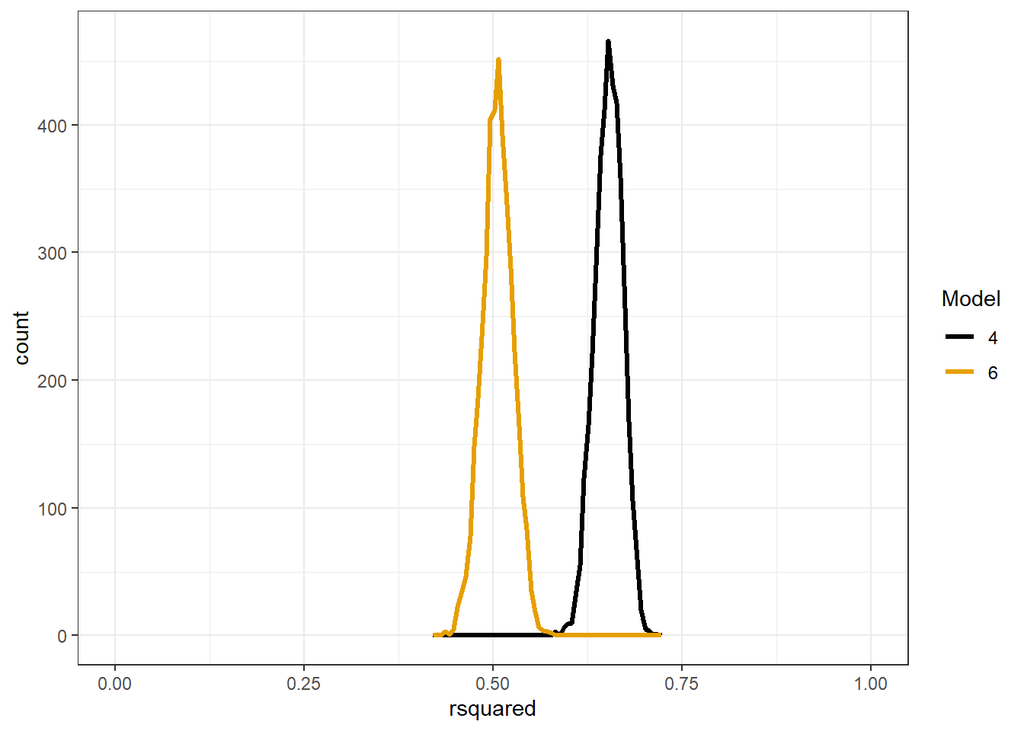

```r
purrr::map2_dfr(
    list(bayesian_model6, bayesian_model4),
    as.character(c("6", "4")),
    function(mod, mod_name){
      tibble::tibble(rsquared = bayes_R2(mod)) %>%
        mutate(model_name = mod_name)
    }
  ) %>%
  ggplot(mapping = aes(x = rsquared)) +
  geom_freqpoly(
    bins = 55,
    mapping = aes(color = model_name),
    size = 1.1) +
  coord_cartesian(xlim = c(0, 1)) +
  ggthemes::scale_color_colorblind("Model") +
  theme_bw()
```

Under the current formulation, Model 4 seems to have the best posterior R^2.

## Posterior noise

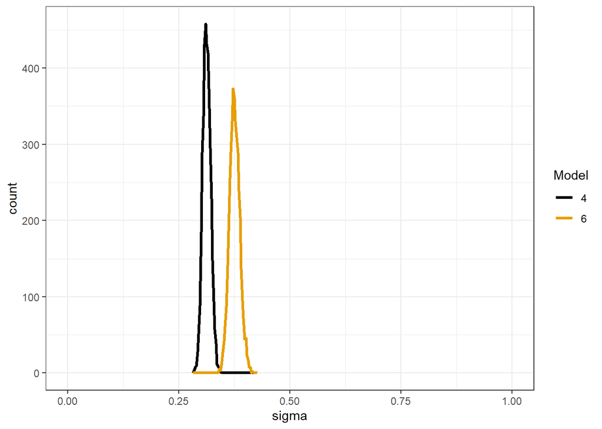

```r
purrr::map2_dfr(
    list(bayesian_model6, bayesian_model4),
    as.character(c("6", "4")),
    function(mod, mod_name){
      as.data.frame(mod) %>%
        tibble::as_tibble() %>%
        select(sigma) %>%
        mutate(model_name = mod_name)
    }
  ) %>%
  ggplot(mapping = aes(x = sigma)) +
    geom_freqpoly(
      bins = 55,
      mapping = aes(color = model_name),
      size = 1.1) +
  coord_cartesian(xlim = c(0, 1)) +
  ggthemes::scale_color_colorblind("Model") +
  theme_bw()
```

Similarly, the posterior noise on Model 4 is slightly lower. Of our Bayesian models, 4 is looking pretty good.

## WAIC

We can examine the WAIC to get another perspective on how these models relate to each other. Let’s calculate it and attach it to the model objects, then compare them:

```r
bayesian_model6$waic <- waic(bayesian_model6)
bayesian_model4$waic <- waic(bayesian_model4)
```

```
## Warning:
## 39 (5.8%) p_waic estimates greater than 0.4. We recommend trying loo instead.
```

```r
all_models <- stanreg_list(
  bayesian_model6, bayesian_model4,
  model_names = c(
    "All sentiment features (pairwise interactions)",
    "Interacting region with continuous inputs"
  )
)

loo_compare(all_models, criterion = "waic")
```

```
## Model comparison based on WAIC:
##                                                elpd_diff se_diff
## Interacting region with continuous inputs         0.0       0.0
## All sentiment features (pairwise interactions) -234.7      21.4
```

Okay, I’ll try to follow the warning messages.

## LOOIC

I did a little bit of looking at LOOIC, and it sounds like a Bayesian equivalent of other IC-style metrics. Which means that I don’t exactly know how it works, but let’s look at it.

```r
loo_6 <- loo(bayesian_model6)
```

```
## Warning: Found 94 observations with a pareto_k > 0.7. With this many problematic observations we recommend calling 'kfold' with argument 'K=10' to perform 10-fold cross-validation rather than LOO.
```

```r
loo_4 <- loo(bayesian_model4)
```

```
## Warning: Found 3 observation(s) with a pareto_k > 0.7. We recommend calling 'loo' again with argument 'k_threshold = 0.7' in order to calculate the ELPD without the assumption that these observations are negligible. This will refit the model 3 times to compute the ELPDs for the problematic observ…
```

```r
loo_compare(loo_6, loo_4)
```

```
##                 elpd_diff se_diff
## bayesian_model4    0.0       0.0
## bayesian_model6 -274.6      21.8
```

# Analysis of the winning model

## Coefficient distributions

Let’s start by visualizing the coefficients of the model:

[figure not shown]

```r
visualize_bayesian_coefficients(bayesian_model4)
```

```r
get_significant_bayesian_coefficients(bayesian_model4)
```

```
## # A tibble: 8 x 3
##   rowname            `5%`   `95%`
##   <chr>             <dbl>   <dbl>
## 1 regionYY:xn_04 -1.22    -0.0555
## 2 R2              0.622    0.682
## 3 regionYY:xb_07 -0.525   -0.0430
## 4 sigma           0.299    0.327
## 5 xn_04           0.0969   0.954
## 6 xb_07           0.0230   0.386
## 7 xb_02           0.00425  0.0805
## 8 regionYY:xn_07  0.00166  0.494
```

An interesting thing to note here is that `xb_07` is one of the predictors we saw doing big work in the previous section, so it’s nice that it shows up here. It seems like a good predictor. `region` also shows up in both places, suggesting that it’s a good predictor.

## Quantiles for R^2 and noise

```r
rstanarm::bayes_R2(bayesian_model4) %>% quantile(c(.05, .5, .95))
```

```
##        5%       50%       95%
## 0.6216264 0.6533793 0.6822481
```

```r
bayesian_model4 %>%
  as_tibble() %>%
  pull(sigma) %>%
  quantile(c(.05, .5, .95))
```

```
##        5%       50%       95%
## 0.2988478 0.3121201 0.3274513
```

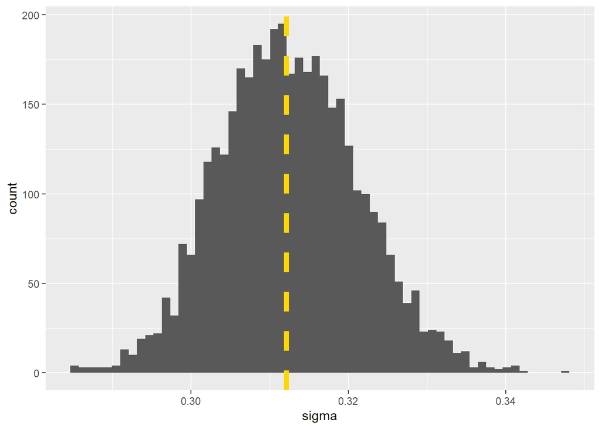

```r
bayesian_model4 %>%
  as.data.frame %>%
  as_tibble %>%
  ggplot(mapping = aes(x = sigma)) +
  geom_histogram(bins = 60) +
  geom_vline(xintercept = sigma(lm_model4$finalModel), color = "lightblue", linetype = "dashed", size = 2) +
  geom_vline(mapping = aes(xintercept = median(sigma)), color = "gold", linetype="dashed", size = 2)
```

## Precision on the posterior $\sigma$: How certain are we?

```r
bayesian_model4 %>%
  as.data.frame %>%
  as_tibble %>%
  pull(sigma) %>%
  sd
```

```
## [1] 0.008844459
```

The standard deviation of the posterior samples on sigma is very low, suggesting that we’re pretty sure that our estimation of the amount of noise is accurate.